# Coursera JHU Getting and Cleaning Data Course Project

Autogenerated data summary from dataMaid

2021-02-04 04:14:42

# Data report overview

The dataset examined has the following dimensions:

| Feature | Result |
| --- | --- |
| Number of observations | 10299 |
| Number of variables | 68 |

### Checks performed

The following variable checks were performed, depending on the data type of each variable:

|  | character | factor | labelled | haven labelled | numeric | integer | logical | Date |
| --- | --- | --- | --- | --- | --- | --- | --- | --- |
| Identify miscoded missing values | × | × | × | × | × | × |  | × |
| Identify prefixed and suffixed whitespace | × | × | × | × |  |  |  |  |
| Identify levels with < 6 obs. | × | × | × | × |  |  |  |  |
| Identify case issues | × | × | × | × |  |  |  |  |
| Identify misclassified numeric or integer variables | × | × | × | × |  |  |  |  |
| Identify outliers |  |  |  |  | × | × |  | × |

# Codebook summary table

| Label | Variable | Class | # unique values | Missing | Description |
| --- | --- | --- | --- | --- | --- |
|  | **activity** | character | 6 | 0.00 % |  |
|  | **fBodyAcc-mean()-X** | numeric | 10295 | 0.00 % |  |
|  | **fBodyAcc-mean()-Y** | numeric | 10292 | 0.00 % |  |
|  | **fBodyAcc-mean()-Z** | numeric | 10295 | 0.00 % |  |
|  | **fBodyAcc-std()-X** | numeric | 10294 | 0.00 % |  |
|  | **fBodyAcc-std()-Y** | numeric | 10297 | 0.00 % |  |
|  | **fBodyAcc-std()-Z** | numeric | 10296 | 0.00 % |  |
|  | **fBodyAccJerk-mean()-X** | numeric | 10293 | 0.00 % |  |
|  | **fBodyAccJerk-mean()-Y** | numeric | 10296 | 0.00 % |  |
|  | **fBodyAccJerk-mean()-Z** | numeric | 10294 | 0.00 % |  |
|  | **fBodyAccJerk-std()-X** | numeric | 10291 | 0.00 % |  |
|  | **fBodyAccJerk-std()-Y** | numeric | 10294 | 0.00 % |  |
|  | **fBodyAccJerk-std()-Z** | numeric | 10290 | 0.00 % |  |
|  | **fBodyAccMag-mean()** | numeric | 10296 | 0.00 % |  |
|  | **fBodyAccMag-std()** | numeric | 10298 | 0.00 % |  |
|  | **fBodyBodyAccJerkMag-mean()** | numeric | 10290 | 0.00 % |  |
|  | **fBodyBodyAccJerkMag-std()** | numeric | 10296 | 0.00 % |  |
|  | **fBodyBodyGyroJerkMag-mean()** | numeric | 10293 | 0.00 % |  |
|  | **fBodyBodyGyroJerkMag-std()** | numeric | 10292 | 0.00 % |  |
|  | **fBodyBodyGyroMag-mean()** | numeric | 10297 | 0.00 % |  |
|  | **fBodyBodyGyroMag-std()** | numeric | 10296 | 0.00 % |  |
|  | **fBodyGyro-mean()-X** | numeric | 10297 | 0.00 % |  |
|  | **fBodyGyro-mean()-Y** | numeric | 10296 | 0.00 % |  |
|  | **fBodyGyro-mean()-Z** | numeric | 10297 | 0.00 % |  |
|  | **fBodyGyro-std()-X** | numeric | 10297 | 0.00 % |  |
|  | **fBodyGyro-std()-Y** | numeric | 10293 | 0.00 % |  |
|  | **fBodyGyro-std()-Z** | numeric | 10295 | 0.00 % |  |
|  | **subjectId** | character | 30 | 0.00 % |  |
|  | **tBodyAcc-mean()-X** | numeric | 10292 | 0.00 % |  |
|  | **tBodyAcc-mean()-Y** | numeric | 10299 | 0.00 % |  |
|  | **tBodyAcc-mean()-Z** | numeric | 10293 | 0.00 % |  |
|  | **tBodyAcc-std()-X** | numeric | 10295 | 0.00 % |  |
|  | **tBodyAcc-std()-Y** | numeric | 10297 | 0.00 % |  |
|  | **tBodyAcc-std()-Z** | numeric | 10297 | 0.00 % |  |
|  | **tBodyAccJerk-mean()-X** | numeric | 10299 | 0.00 % |  |
|  | **tBodyAccJerk-mean()-Y** | numeric | 10299 | 0.00 % |  |
|  | **tBodyAccJerk-mean()-Z** | numeric | 10299 | 0.00 % |  |
|  | **tBodyAccJerk-std()-X** | numeric | 10290 | 0.00 % |  |
|  | **tBodyAccJerk-std()-Y** | numeric | 10296 | 0.00 % |  |
|  | **tBodyAccJerk-std()-Z** | numeric | 10293 | 0.00 % |  |
|  | **tBodyAccJerkMag-mean()** | numeric | 10292 | 0.00 % |  |
|  | **tBodyAccJerkMag-std()** | numeric | 10294 | 0.00 % |  |
|  | **tBodyAccMag-mean()** | numeric | 10296 | 0.00 % |  |
|  | **tBodyAccMag-std()** | numeric | 10294 | 0.00 % |  |
|  | **tBodyGyro-mean()-X** | numeric | 10298 | 0.00 % |  |
|  | **tBodyGyro-mean()-Y** | numeric | 10299 | 0.00 % |  |
|  | **tBodyGyro-mean()-Z** | numeric | 10297 | 0.00 % |  |
|  | **tBodyGyro-std()-X** | numeric | 10292 | 0.00 % |  |
|  | **tBodyGyro-std()-Y** | numeric | 10296 | 0.00 % |  |
|  | **tBodyGyro-std()-Z** | numeric | 10296 | 0.00 % |  |
|  | **tBodyGyroJerk-mean()-X** | numeric | 10295 | 0.00 % |  |
|  | **tBodyGyroJerk-mean()-Y** | numeric | 10299 | 0.00 % |  |
|  | **tBodyGyroJerk-mean()-Z** | numeric | 10298 | 0.00 % |  |
|  | **tBodyGyroJerk-std()-X** | numeric | 10292 | 0.00 % |  |
|  | **tBodyGyroJerk-std()-Y** | numeric | 10295 | 0.00 % |  |
|  | **tBodyGyroJerk-std()-Z** | numeric | 10291 | 0.00 % |  |
|  | **tBodyGyroJerkMag-mean()** | numeric | 10293 | 0.00 % |  |
|  | **tBodyGyroJerkMag-std()** | numeric | 10297 | 0.00 % |  |
|  | **tBodyGyroMag-mean()** | numeric | 10298 | 0.00 % |  |
|  | **tBodyGyroMag-std()** | numeric | 10298 | 0.00 % |  |
|  | **tGravityAcc-mean()-X** | numeric | 10296 | 0.00 % |  |
|  | **tGravityAcc-mean()-Y** | numeric | 10298 | 0.00 % |  |
|  | **tGravityAcc-mean()-Z** | numeric | 10299 | 0.00 % |  |
|  | **tGravityAcc-std()-X** | numeric | 10288 | 0.00 % |  |
|  | **tGravityAcc-std()-Y** | numeric | 10293 | 0.00 % |  |
|  | **tGravityAcc-std()-Z** | numeric | 10296 | 0.00 % |  |
|  | **tGravityAccMag-mean()** | numeric | 10296 | 0.00 % |  |
|  | **tGravityAccMag-std()** | numeric | 10294 | 0.00 % |  |

# Variable list

## activity

| Feature | Result |
| --- | --- |
| Variable type | character |
| Number of missing obs. | 0 (0 %) |
| Number of unique values | 6 |
| Mode | “LAYING” |

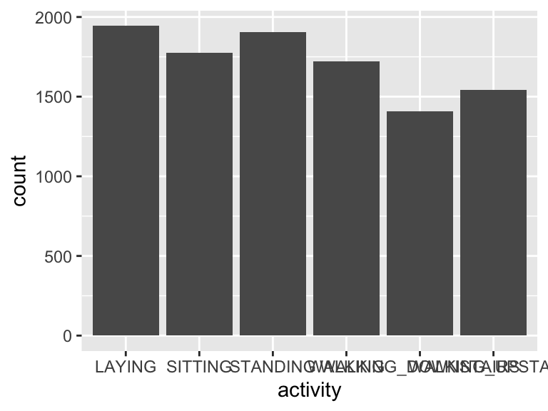

## fBodyAcc-mean()-X

| Feature | Result |
| --- | --- |
| Variable type | numeric |
| Number of missing obs. | 0 (0 %) |
| Number of unique values | 10295 |
| Median | -0.95 |
| 1st and 3rd quartiles | -0.99; -0.26 |
| Min. and max. | -1; 1 |

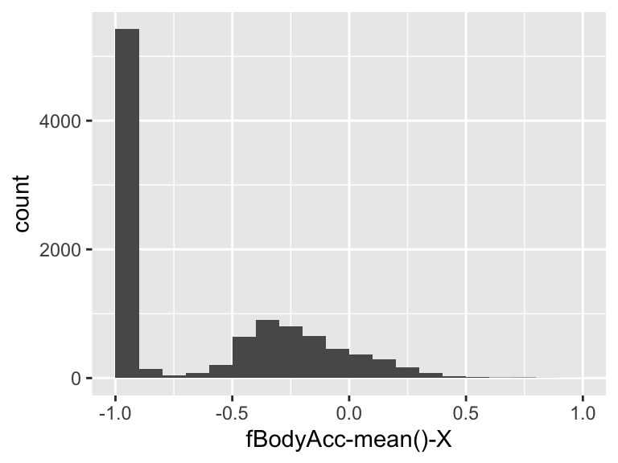

## fBodyAcc-mean()-Y

| Feature | Result |
| --- | --- |
| Variable type | numeric |
| Number of missing obs. | 0 (0 %) |
| Number of unique values | 10292 |
| Median | -0.86 |
| 1st and 3rd quartiles | -0.98; -0.1 |
| Min. and max. | -1; 1 |

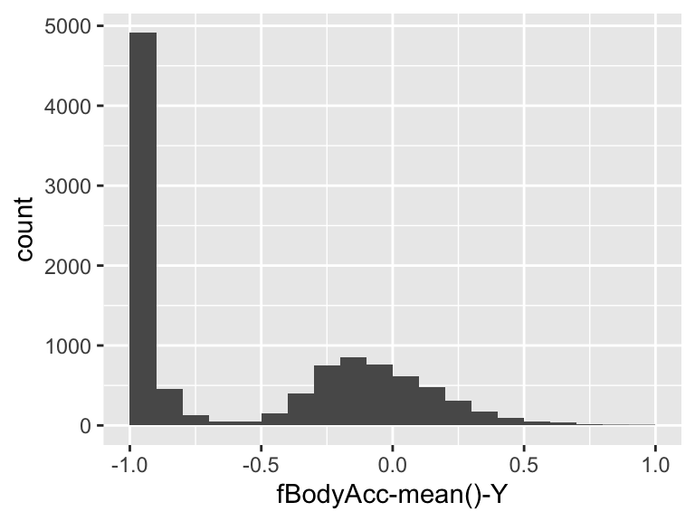

## fBodyAcc-mean()-Z

| Feature | Result |
| --- | --- |
| Variable type | numeric |
| Number of missing obs. | 0 (0 %) |
| Number of unique values | 10295 |
| Median | -0.9 |
| 1st and 3rd quartiles | -0.98; -0.37 |
| Min. and max. | -1; 1 |

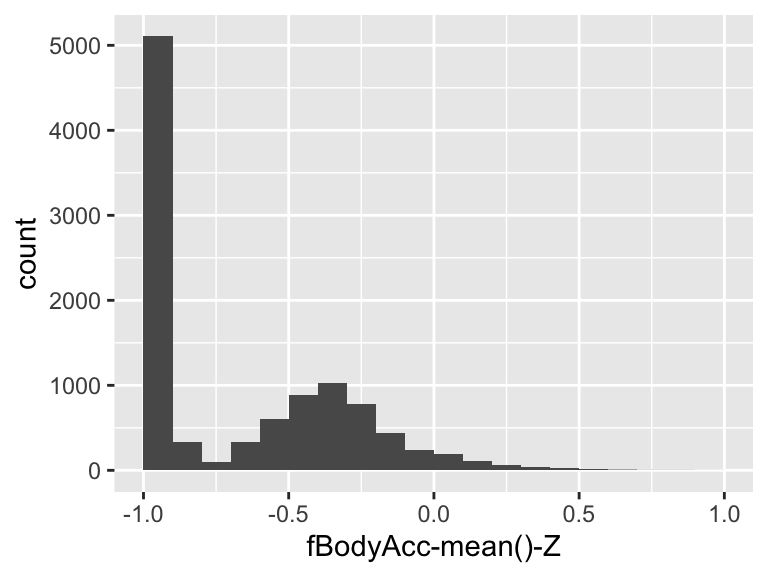

## fBodyAcc-std()-X

| Feature | Result |
| --- | --- |
| Variable type | numeric |
| Number of missing obs. | 0 (0 %) |
| Number of unique values | 10294 |
| Median | -0.94 |
| 1st and 3rd quartiles | -0.99; -0.25 |
| Min. and max. | -1; 1 |

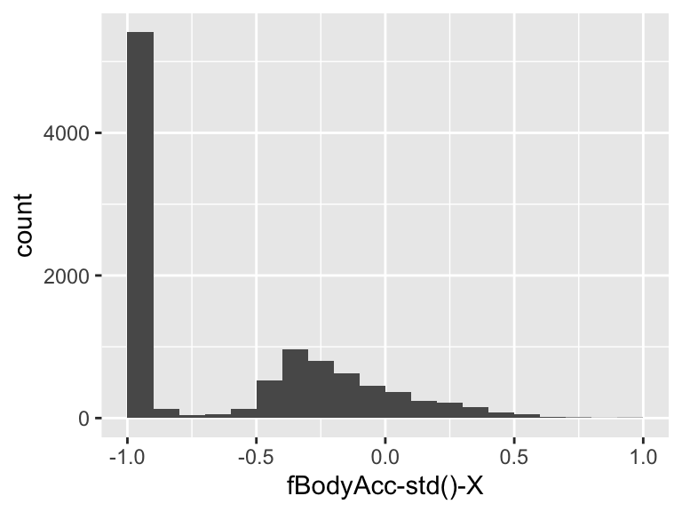

## fBodyAcc-std()-Y

| Feature | Result |
| --- | --- |
| Variable type | numeric |
| Number of missing obs. | 0 (0 %) |
| Number of unique values | 10297 |
| Median | -0.83 |
| 1st and 3rd quartiles | -0.98; -0.09 |
| Min. and max. | -1; 1 |

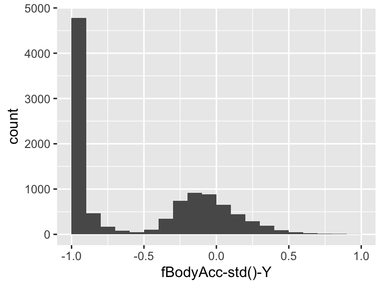

## fBodyAcc-std()-Z

| Feature | Result |
| --- | --- |
| Variable type | numeric |
| Number of missing obs. | 0 (0 %) |
| Number of unique values | 10296 |
| Median | -0.84 |
| 1st and 3rd quartiles | -0.98; -0.3 |
| Min. and max. | -1; 1 |

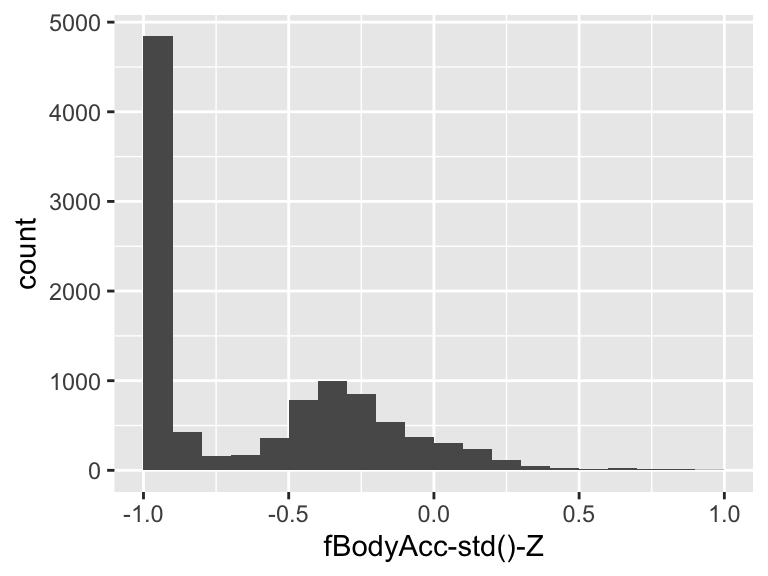

## fBodyAccJerk-mean()-X

| Feature | Result |
| --- | --- |
| Variable type | numeric |
| Number of missing obs. | 0 (0 %) |
| Number of unique values | 10293 |
| Median | -0.95 |
| 1st and 3rd quartiles | -0.99; -0.33 |
| Min. and max. | -1; 1 |

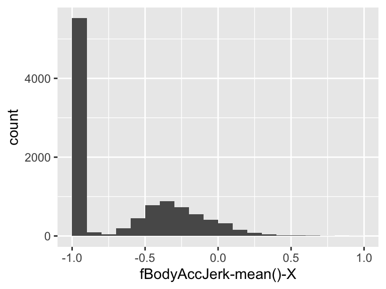

## fBodyAccJerk-mean()-Y

| Feature | Result |
| --- | --- |
| Variable type | numeric |
| Number of missing obs. | 0 (0 %) |
| Number of unique values | 10296 |
| Median | -0.93 |
| 1st and 3rd quartiles | -0.98; -0.26 |
| Min. and max. | -1; 1 |

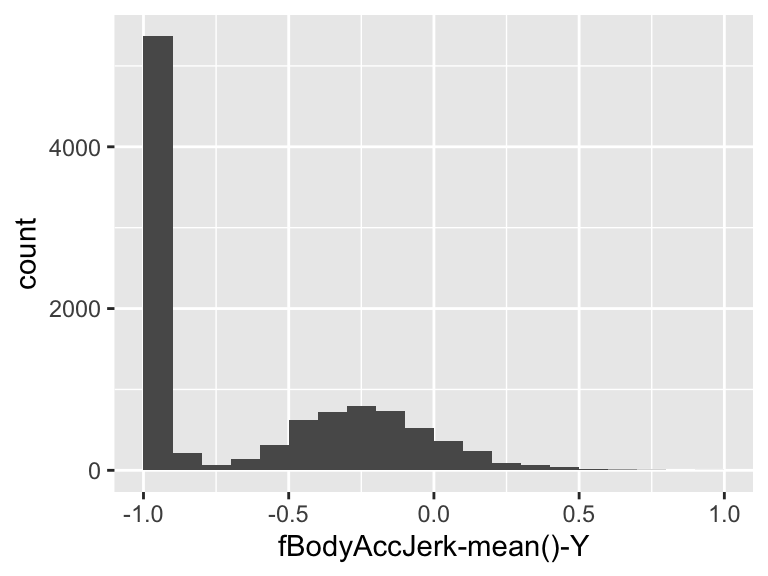

## fBodyAccJerk-mean()-Z

| Feature | Result |
| --- | --- |
| Variable type | numeric |
| Number of missing obs. | 0 (0 %) |
| Number of unique values | 10294 |
| Median | -0.95 |
| 1st and 3rd quartiles | -0.99; -0.51 |
| Min. and max. | -1; 1 |

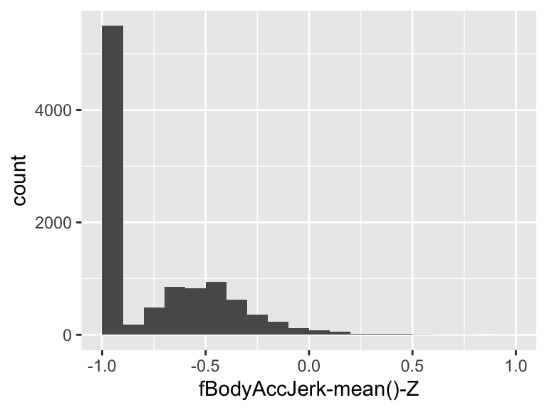

## fBodyAccJerk-std()-X

| Feature | Result |
| --- | --- |
| Variable type | numeric |
| Number of missing obs. | 0 (0 %) |
| Number of unique values | 10291 |
| Median | -0.96 |
| 1st and 3rd quartiles | -0.99; -0.32 |
| Min. and max. | -1; 1 |

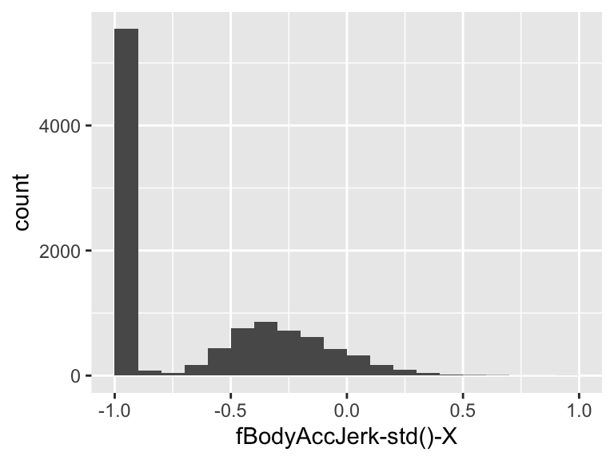

## fBodyAccJerk-std()-Y

| Feature | Result |
| --- | --- |
| Variable type | numeric |
| Number of missing obs. | 0 (0 %) |
| Number of unique values | 10294 |
| Median | -0.93 |
| 1st and 3rd quartiles | -0.99; -0.24 |
| Min. and max. | -1; 1 |

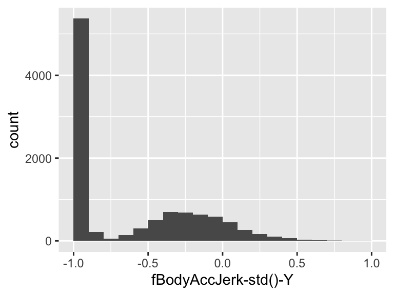

## fBodyAccJerk-std()-Z

| Feature | Result |
| --- | --- |
| Variable type | numeric |
| Number of missing obs. | 0 (0 %) |
| Number of unique values | 10290 |
| Median | -0.96 |
| 1st and 3rd quartiles | -0.99; -0.59 |
| Min. and max. | -1; 1 |

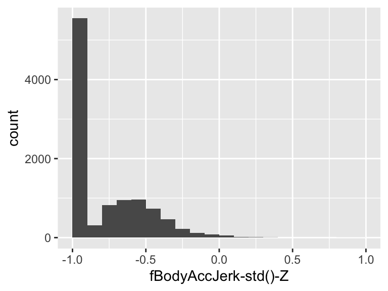

## fBodyAccMag-mean()

| Feature | Result |
| --- | --- |
| Variable type | numeric |
| Number of missing obs. | 0 (0 %) |
| Number of unique values | 10296 |
| Median | -0.88 |
| 1st and 3rd quartiles | -0.98; -0.22 |
| Min. and max. | -1; 1 |

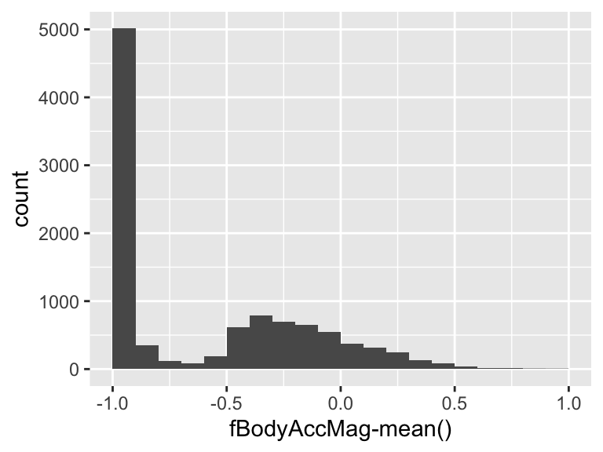

## fBodyAccMag-std()

| Feature | Result |
| --- | --- |
| Variable type | numeric |
| Number of missing obs. | 0 (0 %) |
| Number of unique values | 10298 |
| Median | -0.85 |
| 1st and 3rd quartiles | -0.98; -0.38 |
| Min. and max. | -1; 1 |

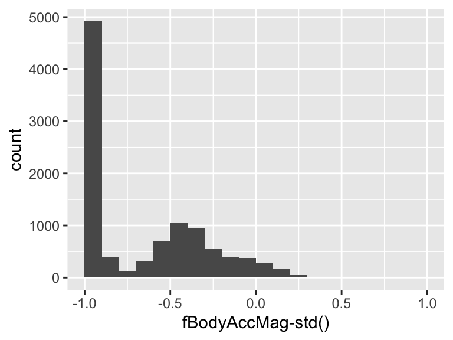

## fBodyBodyAccJerkMag-mean()

| Feature | Result |
| --- | --- |
| Variable type | numeric |
| Number of missing obs. | 0 (0 %) |
| Number of unique values | 10290 |
| Median | -0.93 |
| 1st and 3rd quartiles | -0.99; -0.26 |
| Min. and max. | -1; 1 |

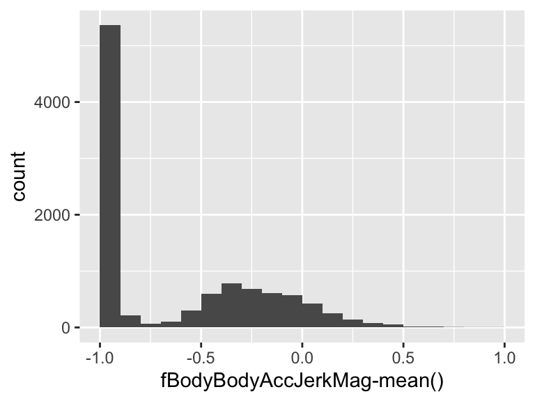

## fBodyBodyAccJerkMag-std()

| Feature | Result |
| --- | --- |
| Variable type | numeric |
| Number of missing obs. | 0 (0 %) |
| Number of unique values | 10296 |
| Median | -0.93 |
| 1st and 3rd quartiles | -0.99; -0.31 |
| Min. and max. | -1; 1 |

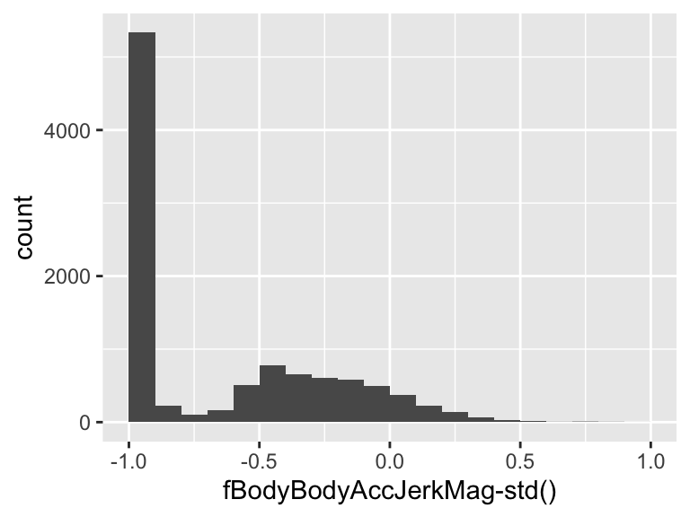

## fBodyBodyGyroJerkMag-mean()

| Feature | Result |
| --- | --- |
| Variable type | numeric |
| Number of missing obs. | 0 (0 %) |
| Number of unique values | 10293 |
| Median | -0.95 |
| 1st and 3rd quartiles | -0.99; -0.61 |
| Min. and max. | -1; 1 |

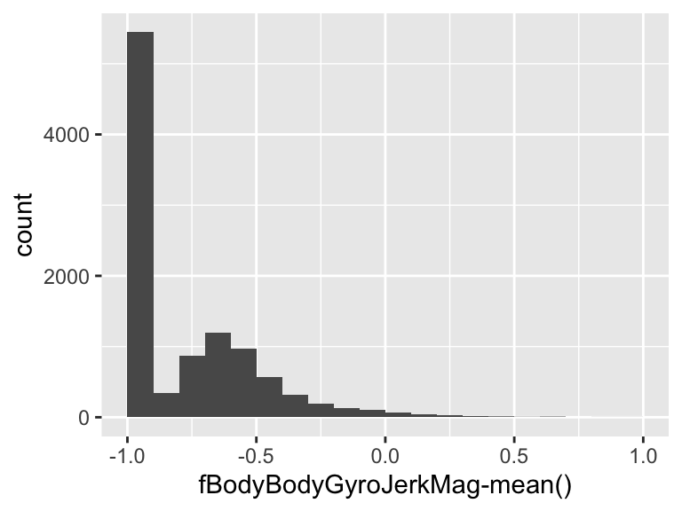

## fBodyBodyGyroJerkMag-std()

| Feature | Result |
| --- | --- |
| Variable type | numeric |
| Number of missing obs. | 0 (0 %) |
| Number of unique values | 10292 |
| Median | -0.94 |
| 1st and 3rd quartiles | -0.99; -0.64 |
| Min. and max. | -1; 1 |

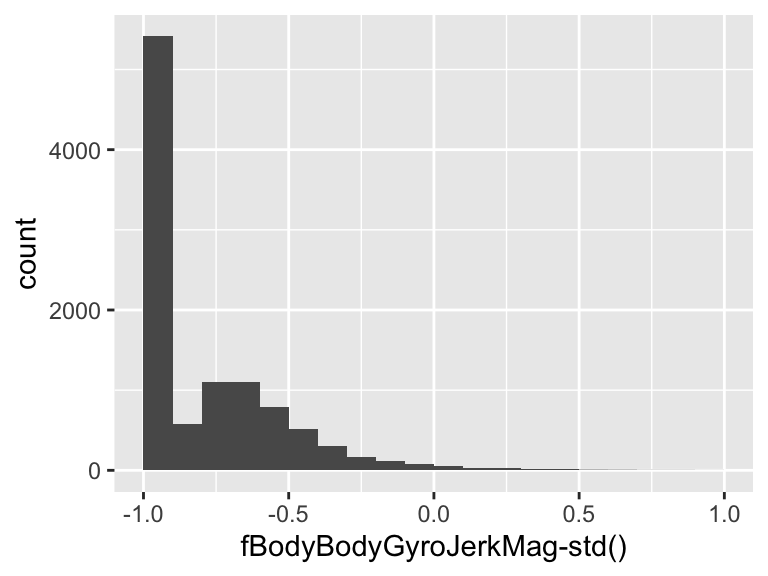

## fBodyBodyGyroMag-mean()

| Feature | Result |
| --- | --- |
| Variable type | numeric |
| Number of missing obs. | 0 (0 %) |
| Number of unique values | 10297 |
| Median | -0.88 |
| 1st and 3rd quartiles | -0.98; -0.45 |
| Min. and max. | -1; 1 |

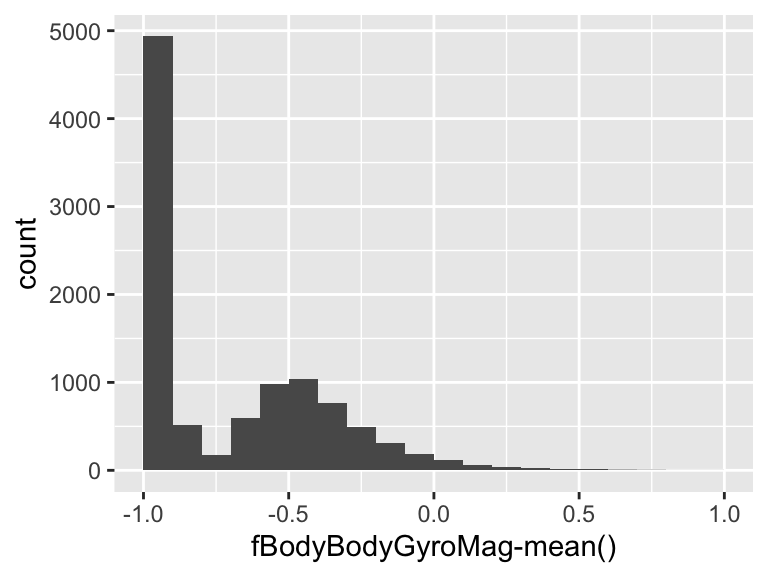

## fBodyBodyGyroMag-std()

| Feature | Result |
| --- | --- |
| Variable type | numeric |
| Number of missing obs. | 0 (0 %) |
| Number of unique values | 10296 |
| Median | -0.83 |
| 1st and 3rd quartiles | -0.98; -0.47 |
| Min. and max. | -1; 1 |

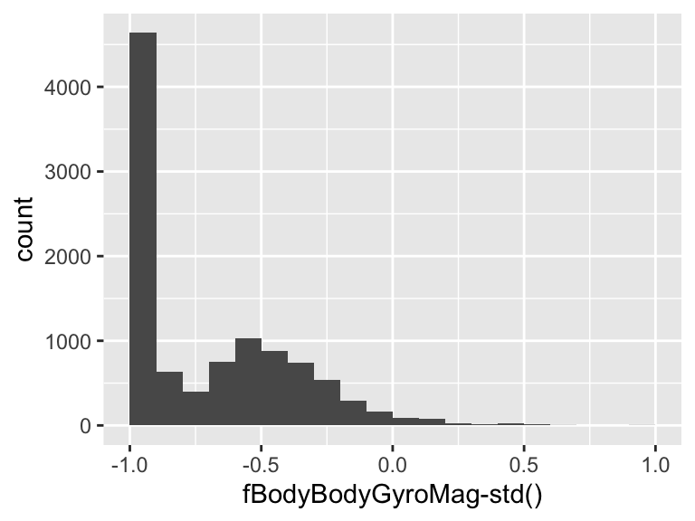

## fBodyGyro-mean()-X

| Feature | Result |
| --- | --- |
| Variable type | numeric |
| Number of missing obs. | 0 (0 %) |
| Number of unique values | 10297 |
| Median | -0.89 |
| 1st and 3rd quartiles | -0.99; -0.38 |
| Min. and max. | -1; 1 |

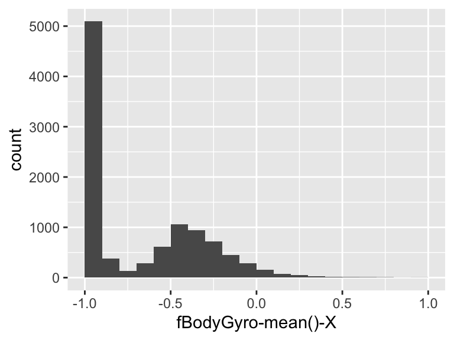

## fBodyGyro-mean()-Y

| Feature | Result |
| --- | --- |
| Variable type | numeric |
| Number of missing obs. | 0 (0 %) |
| Number of unique values | 10296 |
| Median | -0.92 |
| 1st and 3rd quartiles | -0.98; -0.47 |
| Min. and max. | -1; 1 |

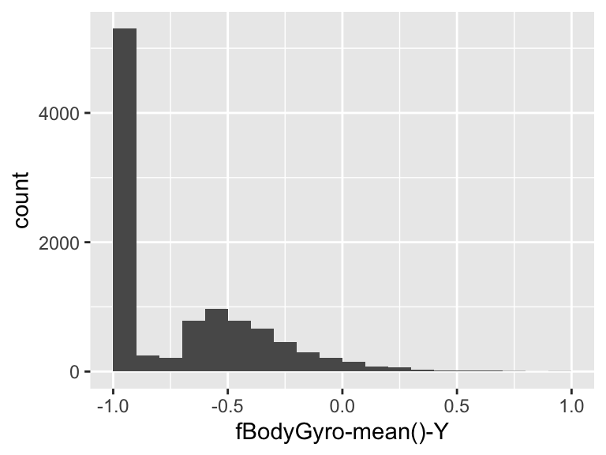

## fBodyGyro-mean()-Z

| Feature | Result |
| --- | --- |
| Variable type | numeric |
| Number of missing obs. | 0 (0 %) |
| Number of unique values | 10297 |
| Median | -0.89 |
| 1st and 3rd quartiles | -0.99; -0.32 |
| Min. and max. | -1; 1 |

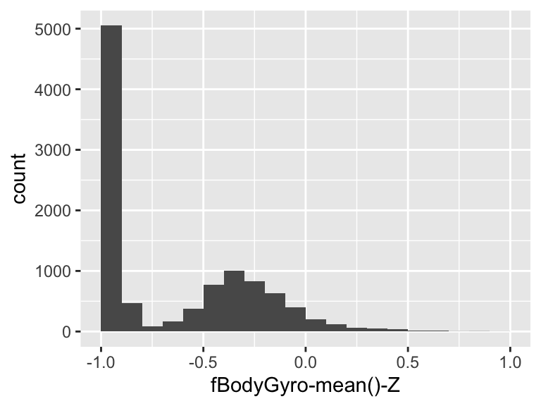

## fBodyGyro-std()-X

| Feature | Result |
| --- | --- |
| Variable type | numeric |
| Number of missing obs. | 0 (0 %) |
| Number of unique values | 10297 |
| Median | -0.91 |
| 1st and 3rd quartiles | -0.99; -0.52 |
| Min. and max. | -1; 1 |

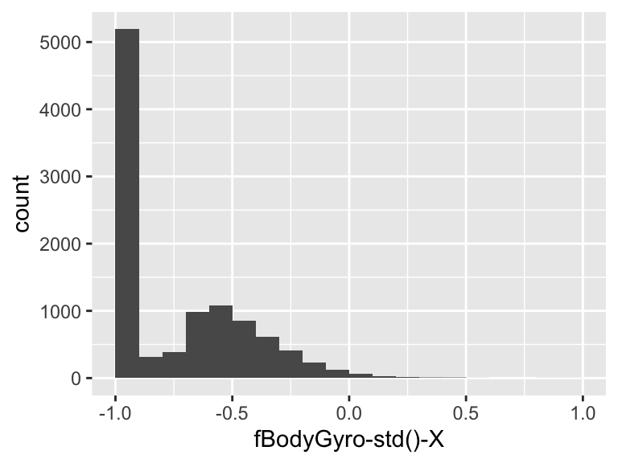

## fBodyGyro-std()-Y

| Feature | Result |
| --- | --- |
| Variable type | numeric |
| Number of missing obs. | 0 (0 %) |
| Number of unique values | 10293 |
| Median | -0.91 |
| 1st and 3rd quartiles | -0.98; -0.44 |
| Min. and max. | -1; 1 |

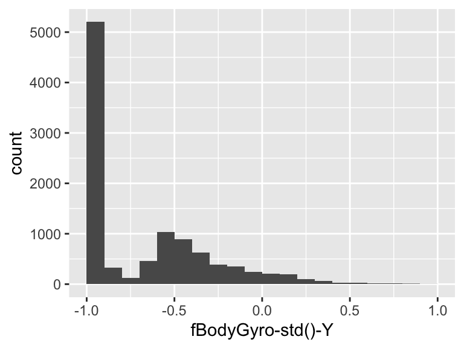

## fBodyGyro-std()-Z

| Feature | Result |
| --- | --- |
| Variable type | numeric |
| Number of missing obs. | 0 (0 %) |
| Number of unique values | 10295 |
| Median | -0.89 |
| 1st and 3rd quartiles | -0.99; -0.42 |
| Min. and max. | -1; 1 |

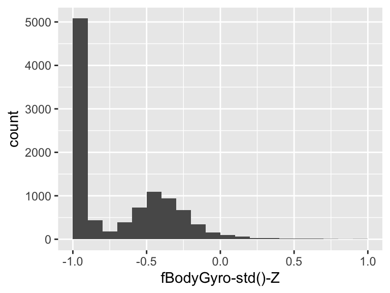

## subjectId

| Feature | Result |
| --- | --- |
| Variable type | character |
| Number of missing obs. | 0 (0 %) |
| Number of unique values | 30 |
| Mode | “25” |

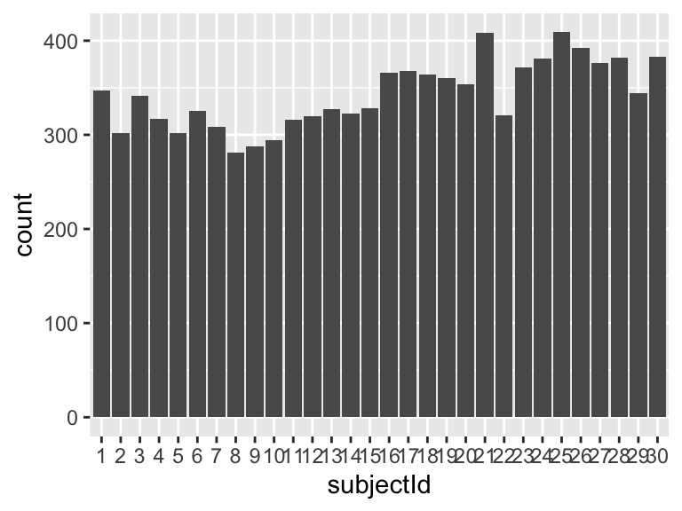

- Note: The variable consists exclusively of numbers and takes a lot of different values. Is it perhaps a misclassified numeric variable?

## tBodyAcc-mean()-X

| Feature | Result |
| --- | --- |
| Variable type | numeric |
| Number of missing obs. | 0 (0 %) |
| Number of unique values | 10292 |
| Median | 0.28 |
| 1st and 3rd quartiles | 0.26; 0.29 |
| Min. and max. | -1; 1 |

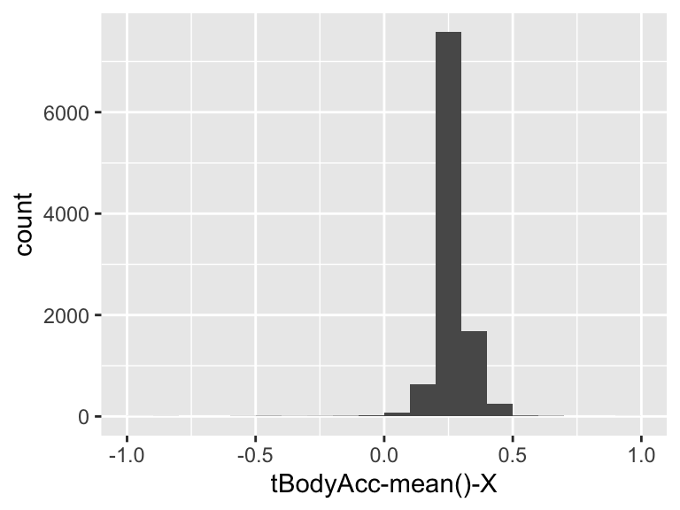

- Note that the following possible outlier values were detected: "-1", "-0.87239538", "-0.85384825", "-0.59200434", "-0.52106206", "-0.50382267", "-0.47255704", "-0.46644048", "-0.4208058", "-0.41627026" (2477 additional values omitted).

## tBodyAcc-mean()-Y

| Feature | Result |
| --- | --- |
| Variable type | numeric |
| Number of missing obs. | 0 (0 %) |
| Number of unique values | 10299 |
| Median | -0.02 |
| 1st and 3rd quartiles | -0.02; -0.01 |
| Min. and max. | -1; 1 |

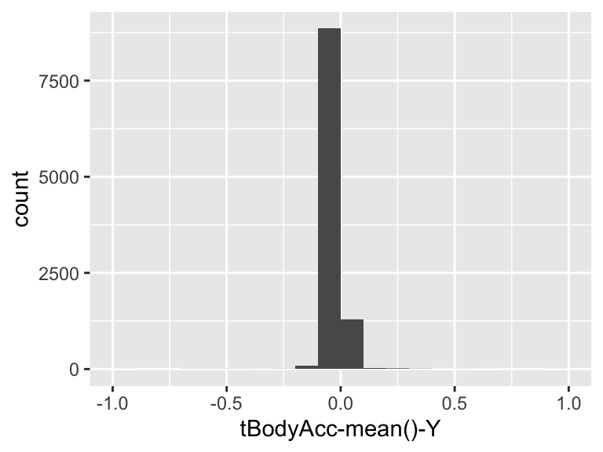

- Note that the following possible outlier values were detected: "-1", "-0.68489328", "-0.68409659", "-0.61809842", "-0.59420738", "-0.54431352", "-0.51873329", "-0.48487956", "-0.4485406", "-0.41386534" (1599 additional values omitted).

## tBodyAcc-mean()-Z

| Feature | Result |
| --- | --- |
| Variable type | numeric |
| Number of missing obs. | 0 (0 %) |
| Number of unique values | 10293 |
| Median | -0.11 |
| 1st and 3rd quartiles | -0.12; -0.1 |
| Min. and max. | -1; 1 |

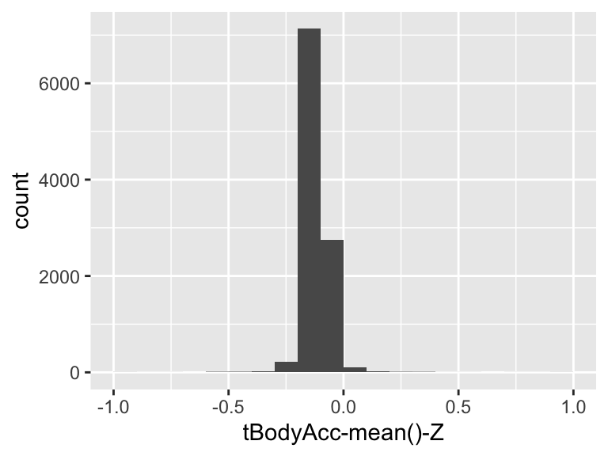

- Note that the following possible outlier values were detected: "-1", "-0.92598834", "-0.82550825", "-0.75752588", "-0.57618401", "-0.57475334", "-0.57420055", "-0.56093378", "-0.51608391", "-0.50964494" (1569 additional values omitted).

## tBodyAcc-std()-X

| Feature | Result |
| --- | --- |
| Variable type | numeric |
| Number of missing obs. | 0 (0 %) |
| Number of unique values | 10295 |
| Median | -0.94 |
| 1st and 3rd quartiles | -0.99; -0.25 |
| Min. and max. | -1; 1 |

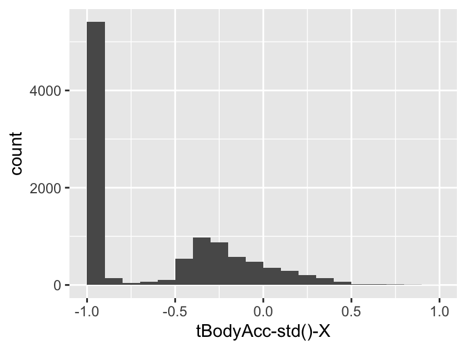

## tBodyAcc-std()-Y

| Feature | Result |
| --- | --- |
| Variable type | numeric |
| Number of missing obs. | 0 (0 %) |
| Number of unique values | 10297 |
| Median | -0.84 |
| 1st and 3rd quartiles | -0.98; -0.06 |
| Min. and max. | -1; 1 |

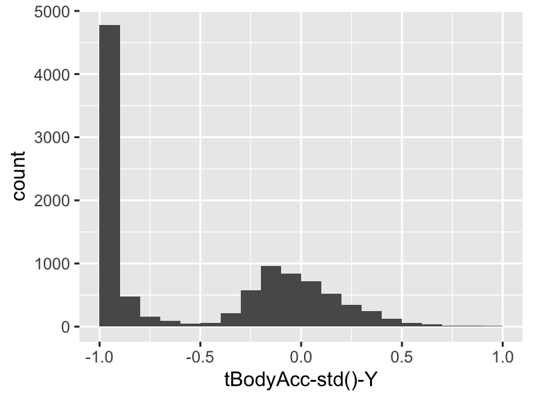

## tBodyAcc-std()-Z

| Feature | Result |
| --- | --- |
| Variable type | numeric |
| Number of missing obs. | 0 (0 %) |
| Number of unique values | 10297 |
| Median | -0.85 |
| 1st and 3rd quartiles | -0.98; -0.28 |
| Min. and max. | -1; 1 |

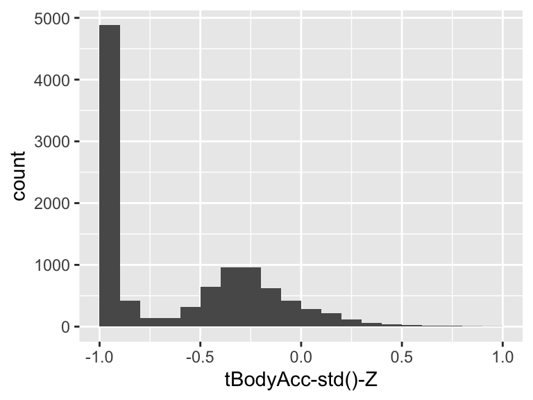

## tBodyAccJerk-mean()-X

| Feature | Result |
| --- | --- |
| Variable type | numeric |
| Number of missing obs. | 0 (0 %) |
| Number of unique values | 10299 |
| Median | 0.08 |
| 1st and 3rd quartiles | 0.06; 0.09 |
| Min. and max. | -1; 1 |

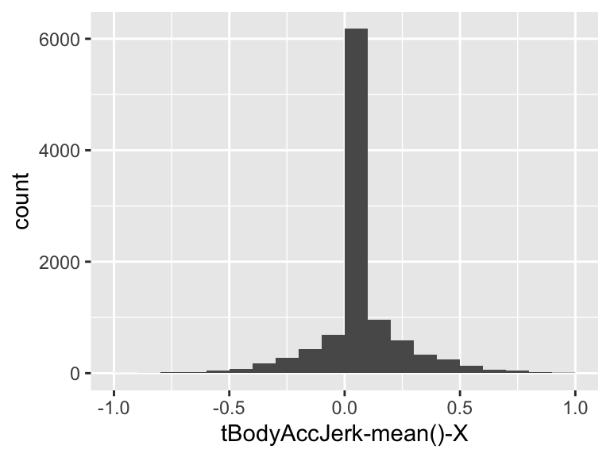

- Note that the following possible outlier values were detected: "-1", "-0.85394626", "-0.83228625", "-0.79923655", "-0.77679071", "-0.76028941", "-0.74726611", "-0.7439812", "-0.74349506", "-0.7389026" (3867 additional values omitted).

## tBodyAccJerk-mean()-Y

| Feature | Result |
| --- | --- |
| Variable type | numeric |
| Number of missing obs. | 0 (0 %) |
| Number of unique values | 10299 |
| Median | 0.01 |
| 1st and 3rd quartiles | -0.02; 0.03 |
| Min. and max. | -1; 1 |

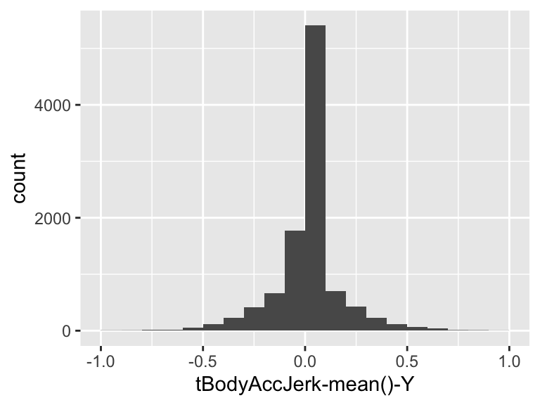

- Note that the following possible outlier values were detected: "-1", "-0.94871415", "-0.94741188", "-0.93249205", "-0.89257378", "-0.82715822", "-0.8184245", "-0.81247415", "-0.80345922", "-0.79328952" (3075 additional values omitted).

## tBodyAccJerk-mean()-Z

| Feature | Result |
| --- | --- |
| Variable type | numeric |
| Number of missing obs. | 0 (0 %) |
| Number of unique values | 10299 |
| Median | 0 |
| 1st and 3rd quartiles | -0.03; 0.02 |
| Min. and max. | -1; 1 |

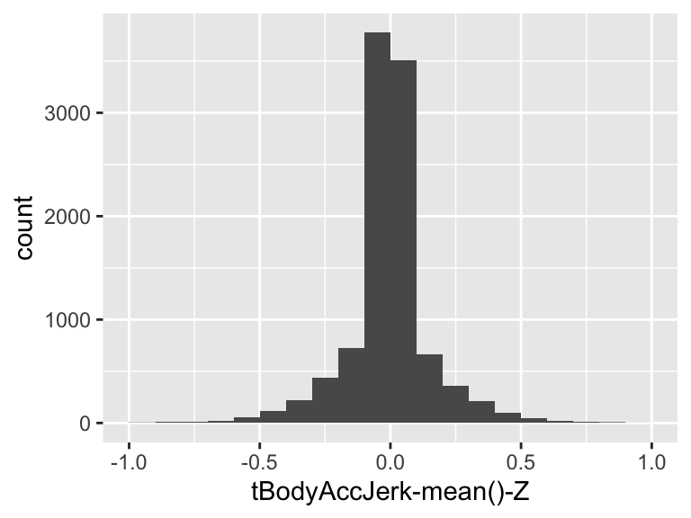

- Note that the following possible outlier values were detected: "-1", "-0.94305695", "-0.90116699", "-0.89868801", "-0.872717", "-0.84628894", "-0.84281809", "-0.82279274", "-0.81169957", "-0.81041821" (2794 additional values omitted).

## tBodyAccJerk-std()-X

| Feature | Result |
| --- | --- |
| Variable type | numeric |
| Number of missing obs. | 0 (0 %) |
| Number of unique values | 10290 |
| Median | -0.95 |
| 1st and 3rd quartiles | -0.99; -0.29 |
| Min. and max. | -1; 1 |

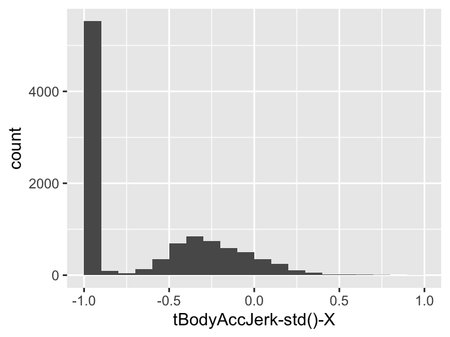

## tBodyAccJerk-std()-Y

| Feature | Result |
| --- | --- |
| Variable type | numeric |
| Number of missing obs. | 0 (0 %) |
| Number of unique values | 10296 |
| Median | -0.93 |
| 1st and 3rd quartiles | -0.99; -0.22 |
| Min. and max. | -1; 1 |

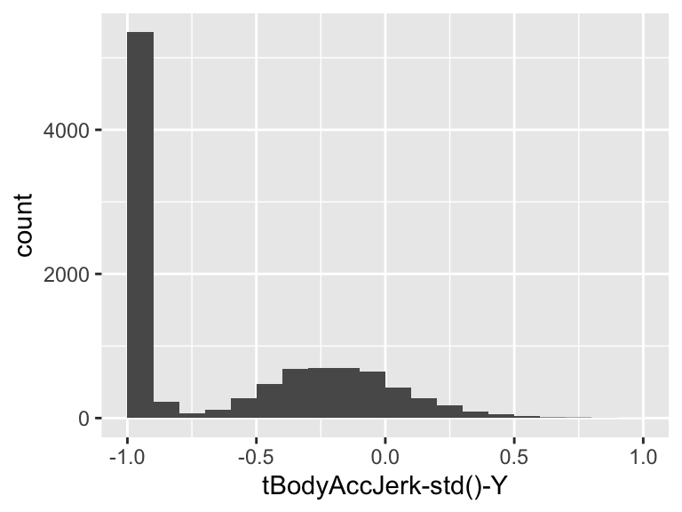

## tBodyAccJerk-std()-Z

| Feature | Result |
| --- | --- |
| Variable type | numeric |
| Number of missing obs. | 0 (0 %) |
| Number of unique values | 10293 |
| Median | -0.95 |
| 1st and 3rd quartiles | -0.99; -0.55 |
| Min. and max. | -1; 1 |

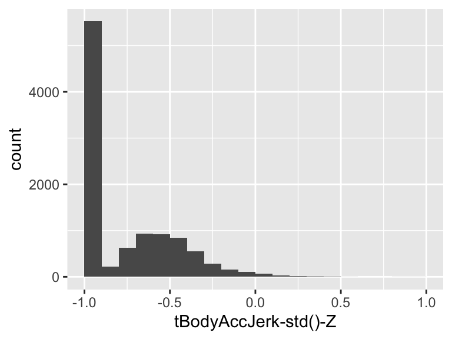

## tBodyAccJerkMag-mean()

| Feature | Result |
| --- | --- |
| Variable type | numeric |
| Number of missing obs. | 0 (0 %) |
| Number of unique values | 10292 |
| Median | -0.95 |
| 1st and 3rd quartiles | -0.99; -0.3 |
| Min. and max. | -1; 1 |

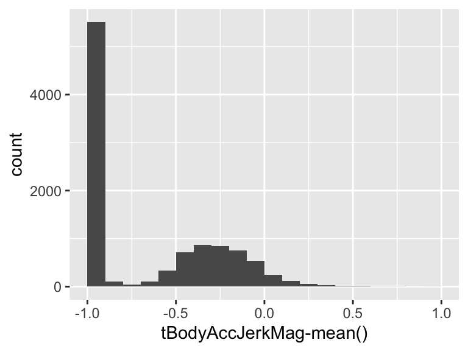

## tBodyAccJerkMag-std()

| Feature | Result |
| --- | --- |
| Variable type | numeric |
| Number of missing obs. | 0 (0 %) |
| Number of unique values | 10294 |
| Median | -0.93 |
| 1st and 3rd quartiles | -0.99; -0.27 |
| Min. and max. | -1; 1 |

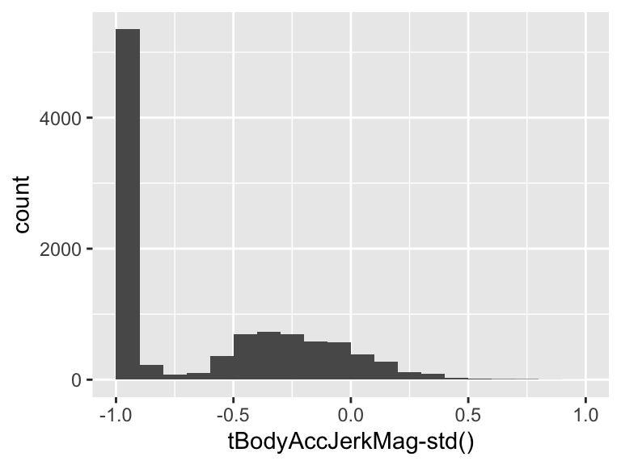

## tBodyAccMag-mean()

| Feature | Result |
| --- | --- |
| Variable type | numeric |
| Number of missing obs. | 0 (0 %) |
| Number of unique values | 10296 |
| Median | -0.87 |
| 1st and 3rd quartiles | -0.98; -0.12 |
| Min. and max. | -1; 1 |

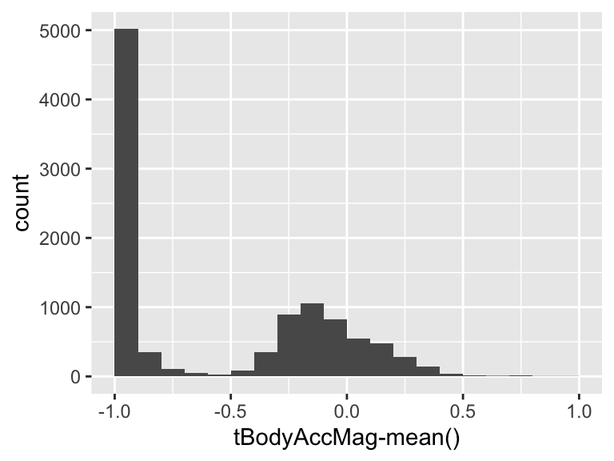

## tBodyAccMag-std()

| Feature | Result |
| --- | --- |
| Variable type | numeric |
| Number of missing obs. | 0 (0 %) |
| Number of unique values | 10294 |
| Median | -0.84 |
| 1st and 3rd quartiles | -0.98; -0.24 |
| Min. and max. | -1; 1 |

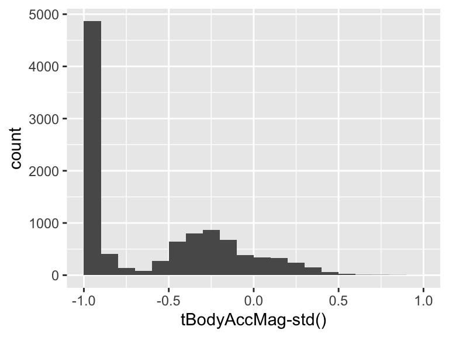

## tBodyGyro-mean()-X

| Feature | Result |
| --- | --- |
| Variable type | numeric |
| Number of missing obs. | 0 (0 %) |
| Number of unique values | 10298 |
| Median | -0.03 |
| 1st and 3rd quartiles | -0.05; -0.01 |
| Min. and max. | -1; 1 |

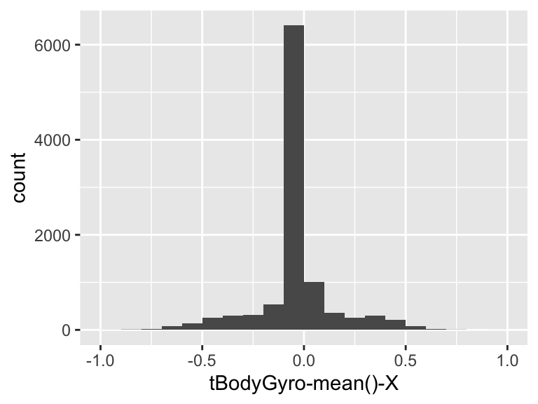

- Note that the following possible outlier values were detected: "-1", "-0.91404957", "-0.82748592", "-0.82605854", "-0.82390857", "-0.81795955", "-0.81564987", "-0.80725006", "-0.78063341", "-0.77330305" (3295 additional values omitted).

## tBodyGyro-mean()-Y

| Feature | Result |
| --- | --- |
| Variable type | numeric |
| Number of missing obs. | 0 (0 %) |
| Number of unique values | 10299 |
| Median | -0.07 |
| 1st and 3rd quartiles | -0.1; -0.05 |
| Min. and max. | -1; 1 |

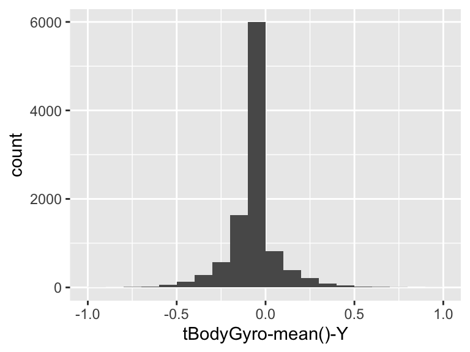

- Note that the following possible outlier values were detected: "-1", "-0.92601988", "-0.85197318", "-0.78365493", "-0.7702705", "-0.76334447", "-0.73225559", "-0.72964565", "-0.72623044", "-0.72526613" (2521 additional values omitted).

## tBodyGyro-mean()-Z

| Feature | Result |
| --- | --- |
| Variable type | numeric |
| Number of missing obs. | 0 (0 %) |
| Number of unique values | 10297 |
| Median | 0.09 |
| 1st and 3rd quartiles | 0.06; 0.11 |
| Min. and max. | -1; 1 |

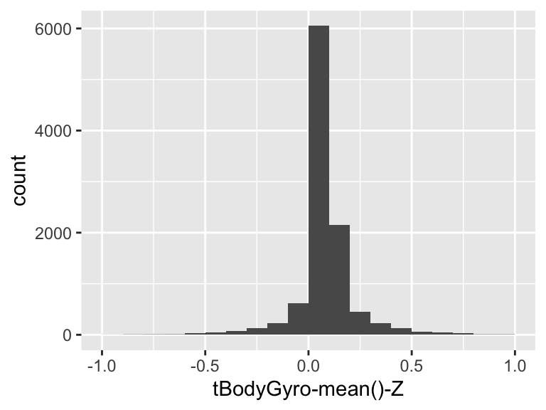

- Note that the following possible outlier values were detected: "-1", "-0.90285978", "-0.85373664", "-0.83573374", "-0.82935879", "-0.82023108", "-0.80671552", "-0.79897208", "-0.75566521", "-0.73188685" (2239 additional values omitted).

## tBodyGyro-std()-X

| Feature | Result |
| --- | --- |
| Variable type | numeric |
| Number of missing obs. | 0 (0 %) |
| Number of unique values | 10292 |
| Median | -0.9 |
| 1st and 3rd quartiles | -0.99; -0.48 |
| Min. and max. | -1; 1 |

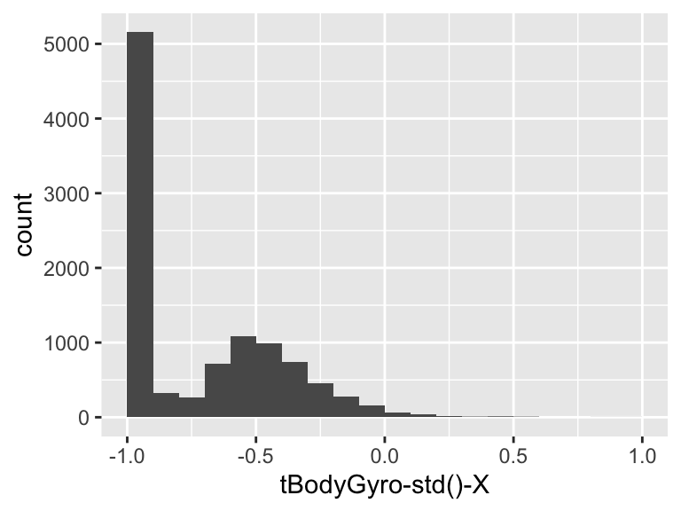

## tBodyGyro-std()-Y

| Feature | Result |
| --- | --- |
| Variable type | numeric |
| Number of missing obs. | 0 (0 %) |
| Number of unique values | 10296 |
| Median | -0.91 |
| 1st and 3rd quartiles | -0.98; -0.45 |
| Min. and max. | -1; 1 |

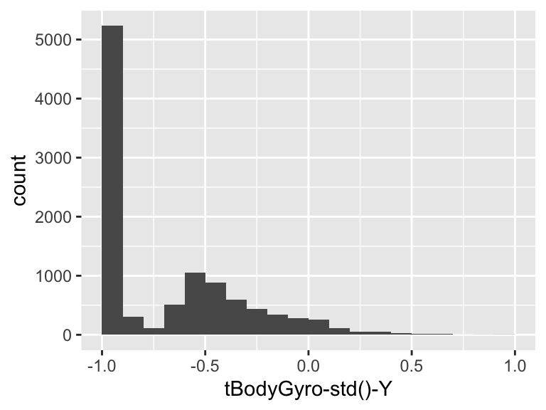

## tBodyGyro-std()-Z

| Feature | Result |
| --- | --- |
| Variable type | numeric |
| Number of missing obs. | 0 (0 %) |
| Number of unique values | 10296 |
| Median | -0.88 |
| 1st and 3rd quartiles | -0.99; -0.34 |
| Min. and max. | -1; 1 |

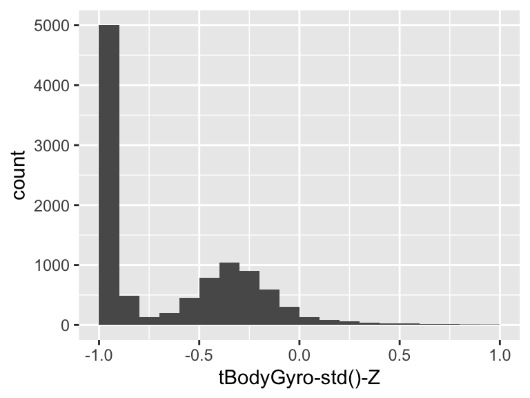

## tBodyGyroJerk-mean()-X

| Feature | Result |
| --- | --- |
| Variable type | numeric |
| Number of missing obs. | 0 (0 %) |
| Number of unique values | 10295 |
| Median | -0.1 |
| 1st and 3rd quartiles | -0.12; -0.08 |
| Min. and max. | -1; 1 |

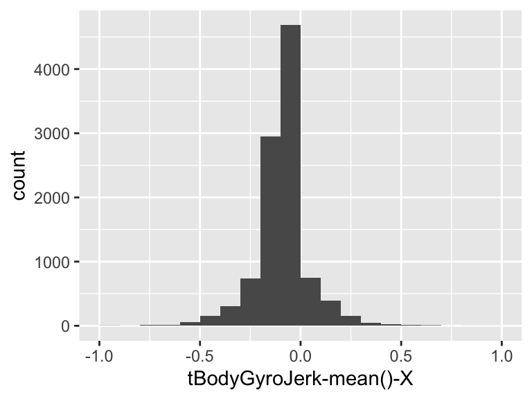

- Note that the following possible outlier values were detected: "-1", "-0.96897595", "-0.95914296", "-0.87193864", "-0.79429092", "-0.79152126", "-0.79016206", "-0.78195071", "-0.7739419", "-0.76314989" (3140 additional values omitted).

## tBodyGyroJerk-mean()-Y

| Feature | Result |
| --- | --- |
| Variable type | numeric |
| Number of missing obs. | 0 (0 %) |
| Number of unique values | 10299 |
| Median | -0.04 |
| 1st and 3rd quartiles | -0.06; -0.03 |
| Min. and max. | -1; 1 |

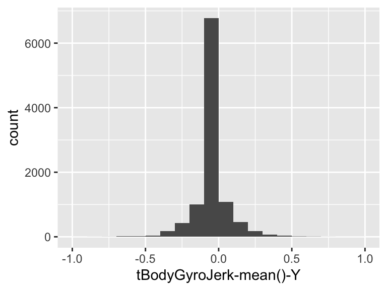

- Note that the following possible outlier values were detected: "-1", "-0.87106661", "-0.8364198", "-0.78104645", "-0.77591766", "-0.71619003", "-0.66611538", "-0.65697158", "-0.64993916", "-0.64429277" (3042 additional values omitted).

## tBodyGyroJerk-mean()-Z

| Feature | Result |
| --- | --- |
| Variable type | numeric |
| Number of missing obs. | 0 (0 %) |
| Number of unique values | 10298 |
| Median | -0.05 |
| 1st and 3rd quartiles | -0.08; -0.03 |
| Min. and max. | -1; 1 |

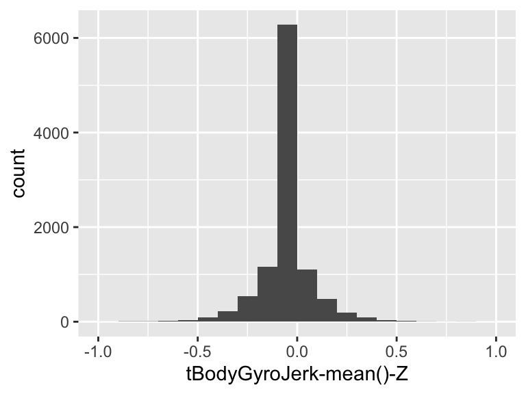

- Note that the following possible outlier values were detected: "-1", "-0.86534747", "-0.84551081", "-0.8259924", "-0.82152497", "-0.81632111", "-0.81442675", "-0.79376803", "-0.74947975", "-0.72724433" (2743 additional values omitted).

## tBodyGyroJerk-std()-X

| Feature | Result |
| --- | --- |
| Variable type | numeric |
| Number of missing obs. | 0 (0 %) |
| Number of unique values | 10292 |
| Median | -0.93 |
| 1st and 3rd quartiles | -0.99; -0.49 |
| Min. and max. | -1; 1 |

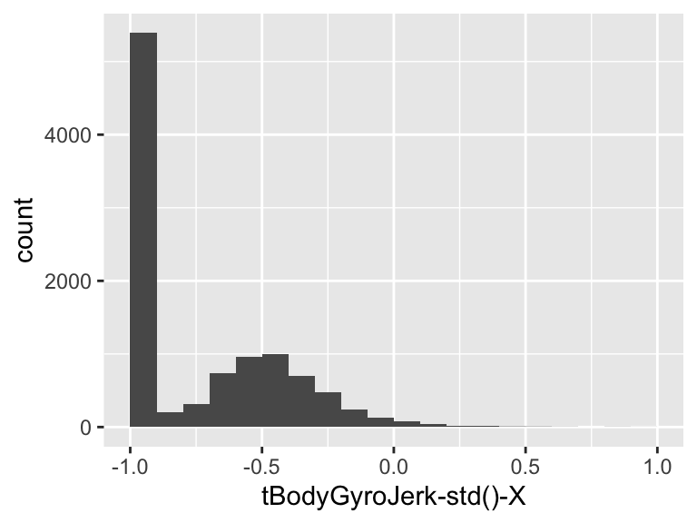

## tBodyGyroJerk-std()-Y

| Feature | Result |
| --- | --- |
| Variable type | numeric |
| Number of missing obs. | 0 (0 %) |
| Number of unique values | 10295 |
| Median | -0.95 |
| 1st and 3rd quartiles | -0.99; -0.63 |
| Min. and max. | -1; 1 |

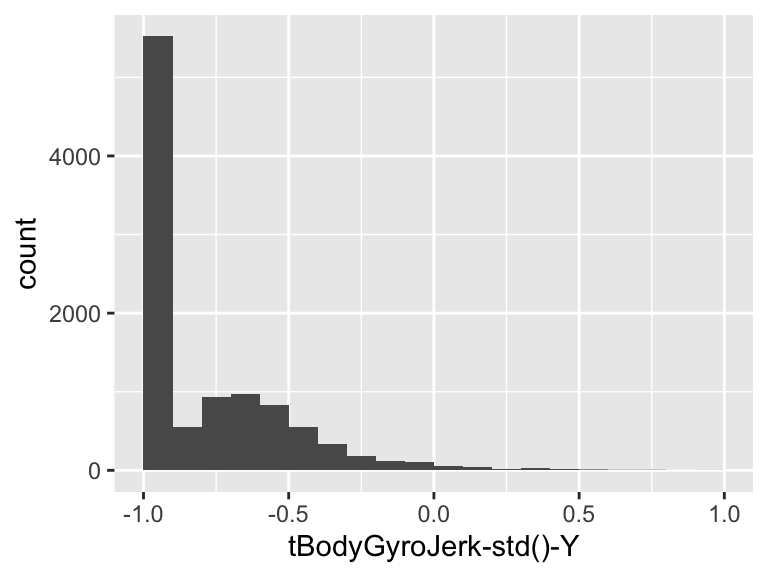

## tBodyGyroJerk-std()-Z

| Feature | Result |
| --- | --- |
| Variable type | numeric |
| Number of missing obs. | 0 (0 %) |
| Number of unique values | 10291 |
| Median | -0.95 |
| 1st and 3rd quartiles | -0.99; -0.51 |
| Min. and max. | -1; 1 |

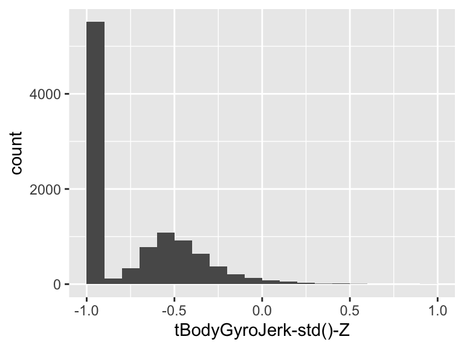

## tBodyGyroJerkMag-mean()

| Feature | Result |
| --- | --- |
| Variable type | numeric |
| Number of missing obs. | 0 (0 %) |
| Number of unique values | 10293 |
| Median | -0.96 |
| 1st and 3rd quartiles | -0.99; -0.55 |
| Min. and max. | -1; 1 |

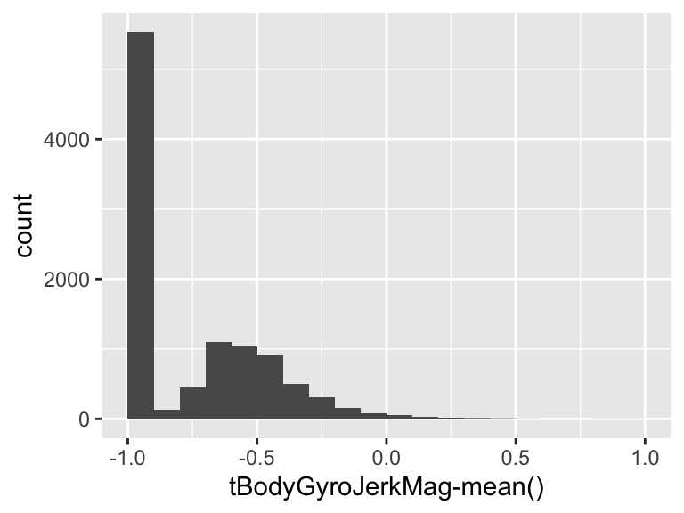

## tBodyGyroJerkMag-std()

| Feature | Result |
| --- | --- |
| Variable type | numeric |
| Number of missing obs. | 0 (0 %) |
| Number of unique values | 10297 |
| Median | -0.94 |
| 1st and 3rd quartiles | -0.99; -0.61 |
| Min. and max. | -1; 1 |

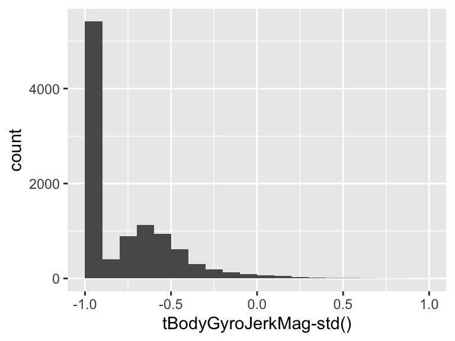

## tBodyGyroMag-mean()

| Feature | Result |
| --- | --- |
| Variable type | numeric |
| Number of missing obs. | 0 (0 %) |
| Number of unique values | 10298 |
| Median | -0.82 |
| 1st and 3rd quartiles | -0.98; -0.25 |
| Min. and max. | -1; 1 |

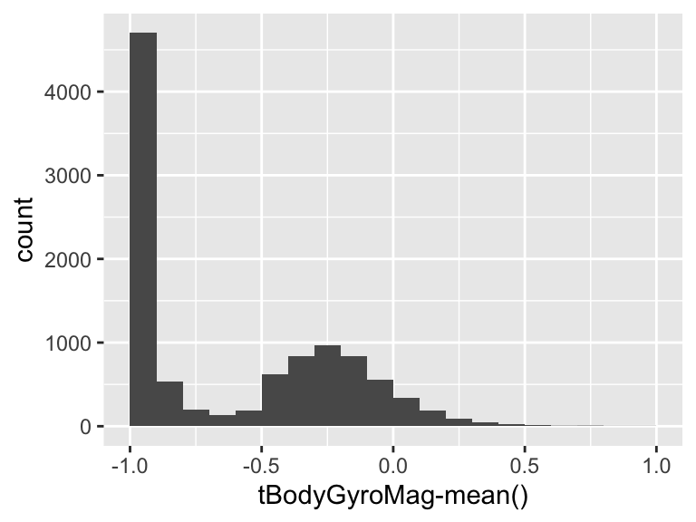

## tBodyGyroMag-std()

| Feature | Result |
| --- | --- |
| Variable type | numeric |
| Number of missing obs. | 0 (0 %) |
| Number of unique values | 10298 |
| Median | -0.83 |
| 1st and 3rd quartiles | -0.98; -0.39 |
| Min. and max. | -1; 1 |

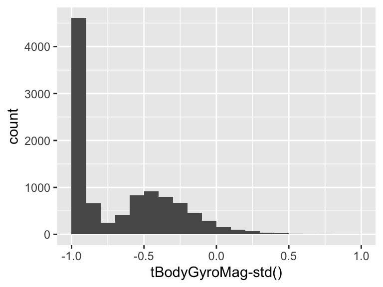

## tGravityAcc-mean()-X

| Feature | Result |
| --- | --- |
| Variable type | numeric |
| Number of missing obs. | 0 (0 %) |
| Number of unique values | 10296 |
| Median | 0.92 |
| 1st and 3rd quartiles | 0.81; 0.95 |
| Min. and max. | -1; 1 |

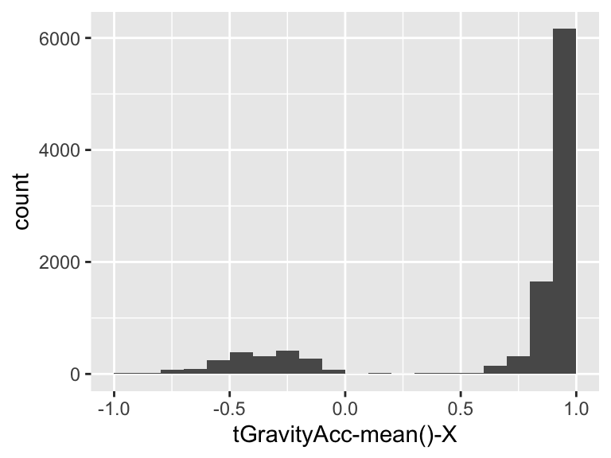

- Note that the following possible outlier values were detected: "-1", "-0.94656635", "-0.94186102", "-0.94021189", "-0.93673012", "-0.93655722", "-0.93354349", "-0.93143761", "-0.93134551", "-0.93108891" (843 additional values omitted).

## tGravityAcc-mean()-Y

| Feature | Result |
| --- | --- |
| Variable type | numeric |
| Number of missing obs. | 0 (0 %) |
| Number of unique values | 10298 |
| Median | -0.14 |
| 1st and 3rd quartiles | -0.24; 0.12 |
| Min. and max. | -1; 1 |

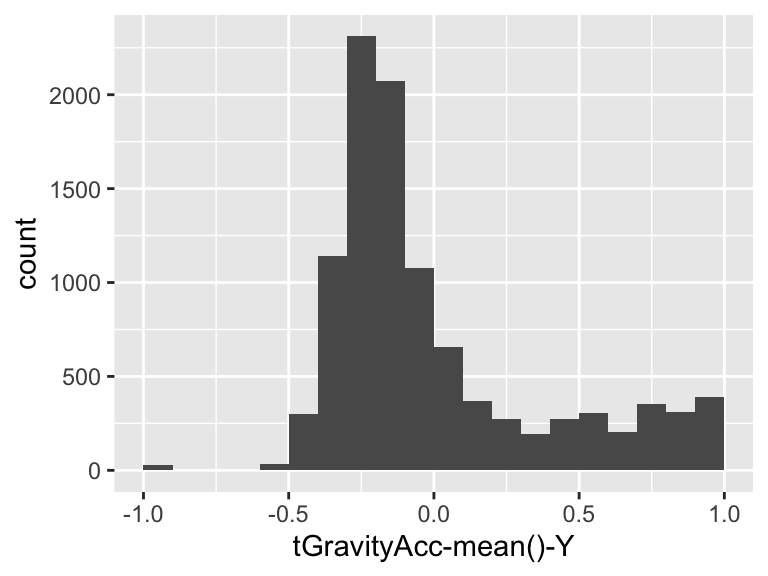

- Note that the following possible outlier values were detected: "-1", "-0.99982049", "-0.99972624", "-0.99967016", "-0.99965287", "-0.99961699", "-0.9989217", "-0.99884273", "-0.99883651", "-0.99881434" (1265 additional values omitted).

## tGravityAcc-mean()-Z

| Feature | Result |
| --- | --- |
| Variable type | numeric |
| Number of missing obs. | 0 (0 %) |
| Number of unique values | 10299 |
| Median | 0.04 |
| 1st and 3rd quartiles | -0.12; 0.22 |
| Min. and max. | -1; 1 |

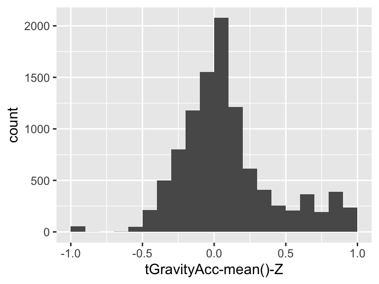

- Note that the following possible outlier values were detected: "-1", "-0.99985803", "-0.99947046", "-0.99945181", "-0.99942508", "-0.99802721", "-0.99759704", "-0.997448", "-0.99680671", "-0.99652573" (434 additional values omitted).